# NosAnalizamos

Marina Moros Sebastià

2026-05-24

## Carga y limpieza automática de ambos ficheros

```r
leer_datos <- function(ruta) {
  lineas <- readLines(ruta, n = 50, warn = FALSE)
  # Buscar la fila que contiene "Id" y "Age" y "Sex" (en cualquier posición)
  fila_cabecera <- which(
    str_detect(lineas, "\\bId\\b") &
    str_detect(lineas, "\\bAge\\b") &
    str_detect(lineas, "\\bSex\\b")
  )[1]
  if (is.na(fila_cabecera)) stop("No se encontró cabecera en ", ruta)

  read_tsv(ruta,
           skip = fila_cabecera - 1,
           col_names = TRUE,
           show_col_types = FALSE,
           locale = locale(encoding = "UTF-8")) %>%
    filter(!is.na(Id) & Id != "" & Id != "Id")
}

datos2022 <- leer_datos("data/NosAutoanalizamos2022 - Hoja1.tsv")
datos2026 <- leer_datos("data/NosAutoanalizamos2026 - NosAutoanalizamos (1).tsv")

datos2022 <- datos2022 %>% filter(Id != "martsobm")
datos2026 <- datos2026 %>% filter(Id != "martsobm")

cat("Alumnos 2022:", nrow(datos2022), "\n")
```

```
## Alumnos 2022: 62
```

```r
cat("Alumnos 2026:", nrow(datos2026), "\n")
```

```
## Alumnos 2026: 60
```

## Limpieza de calificaciones

```r
asignaturas <- c("ALG", "ANM", "FP", "DCS", "MD")

limpia_nota <- function(x) {
  x <- as.character(x)
  x <- str_replace_all(x, ",", ".")
  x <- if_else(toupper(x) == "NC", "3", x)
  suppressWarnings(as.numeric(x))
}

procesar_notas <- function(datos, anyo) {
  notas <- datos %>%
    select(Id, all_of(asignaturas)) %>%
    mutate(across(all_of(asignaturas), limpia_nota))

  if (anyo == "2022") save(notas, file = "Notas.Rdata")
  return(notas)
}

notas2022 <- procesar_notas(datos2022, "2022")
notas2026 <- procesar_notas(datos2026, "2026")

cat("Notas 2022 - primeras filas:\n")
```

```
## Notas 2022 - primeras filas:
```

```r
head(notas2022)
```

```
## # A tibble: 6 × 6
##   Id         ALG   ANM    FP   DCS    MD
##   <chr>    <dbl> <dbl> <dbl> <dbl> <dbl>
## 1 pedelu    10    9.62  NA    8.3   9.3
## 2 salgis     2.8  4     NA    5.11  5.55
## 3 garfal     6.4  6.65  NA    6.5   5.8
## 4 silobor    7.1  7.8   NA    7.5   7
## 5 jamarlli   9.5  9.2    9.5  9     9.4
## 6 mabalo3    1.9  3.4   NA    5.2   2.2
```

```r
cat("\nNotas 2026 - primeras filas:\n")
```

```
##
## Notas 2026 - primeras filas:
```

```r
head(notas2026)
```

```
## # A tibble: 6 × 6
##   Id        ALG   ANM    FP   DCS    MD
##   <chr>   <dbl> <dbl> <dbl> <dbl> <dbl>
## 1 sorivi    3     7.9     3     9   7.8
## 2 magiflo   3    NA       3    NA   6.2
## 3 fuenar2  NA    NA      NA    NA  NA
## 4 lauhori  NA    NA      NA    NA  NA
## 5 Jorica3   3.4   7.6    NA     5   5
## 6 bevili    3.2   6.9    NA     4   4
```

## Tabla de estadísticos

```r
tabla_stats <- function(notas, anyo) {
  notas %>%
    select(all_of(asignaturas)) %>%
    pivot_longer(everything(), names_to = "Asignatura", values_to = "Nota") %>%
    group_by(Asignatura) %>%
    summarise(
      Min     = round(min(Nota,                 na.rm = TRUE), 2),
      P25     = round(quantile(Nota, 0.25,      na.rm = TRUE), 2),
      Mediana = round(median(Nota,              na.rm = TRUE), 2),
      Media   = round(mean(Nota,                na.rm = TRUE), 2),
      SD      = round(sd(Nota,                  na.rm = TRUE), 2),
      P75     = round(quantile(Nota, 0.75,      na.rm = TRUE), 2),
      Max     = round(max(Nota,                 na.rm = TRUE), 2),
      .groups = "drop"
    ) %>%
    kable(caption = paste("Estadísticos curso", anyo))
}

tabla_stats(notas2022, "2022")
```

Estadísticos curso 2022

| Asignatura | Min | P25 | Mediana | Media | SD | P75 | Max |
| --- | --- | --- | --- | --- | --- | --- | --- |
| ALG | 1.9 | 6.00 | 6.72 | 6.41 | 1.65 | 7.50 | 10.00 |
| ANM | 3.4 | 6.97 | 7.90 | 7.61 | 1.45 | 8.50 | 9.81 |
| DCS | 3.0 | 6.79 | 7.65 | 7.42 | 1.36 | 8.30 | 9.80 |
| FP | 3.0 | 3.53 | 6.00 | 5.77 | 2.25 | 7.25 | 9.50 |
| MD | 1.5 | 5.47 | 6.40 | 6.12 | 1.99 | 7.41 | 9.50 |

```r
tabla_stats(notas2026, "2026")
```

Estadísticos curso 2026

| Asignatura | Min | P25 | Mediana | Media | SD | P75 | Max |
| --- | --- | --- | --- | --- | --- | --- | --- |
| ALG | 0.28 | 3.00 | 6.55 | 5.45 | 2.36 | 7.47 | 8.8 |
| ANM | 0.08 | 5.01 | 6.60 | 6.12 | 2.07 | 7.55 | 10.0 |
| DCS | 3.00 | 4.00 | 7.10 | 6.11 | 2.18 | 8.00 | 9.0 |
| FP | 0.80 | 3.00 | 3.00 | 4.40 | 2.39 | 7.00 | 8.6 |
| MD | 2.60 | 5.58 | 6.45 | 6.12 | 1.68 | 7.43 | 8.3 |

## ggpairs

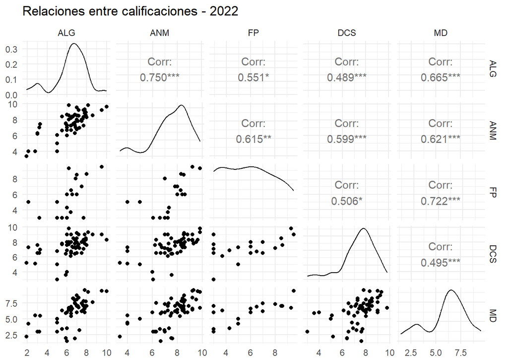

```r
notas2022 %>%
  select(all_of(asignaturas)) %>%
  ggpairs(title = "Relaciones entre calificaciones - 2022") +
  theme_minimal()
```

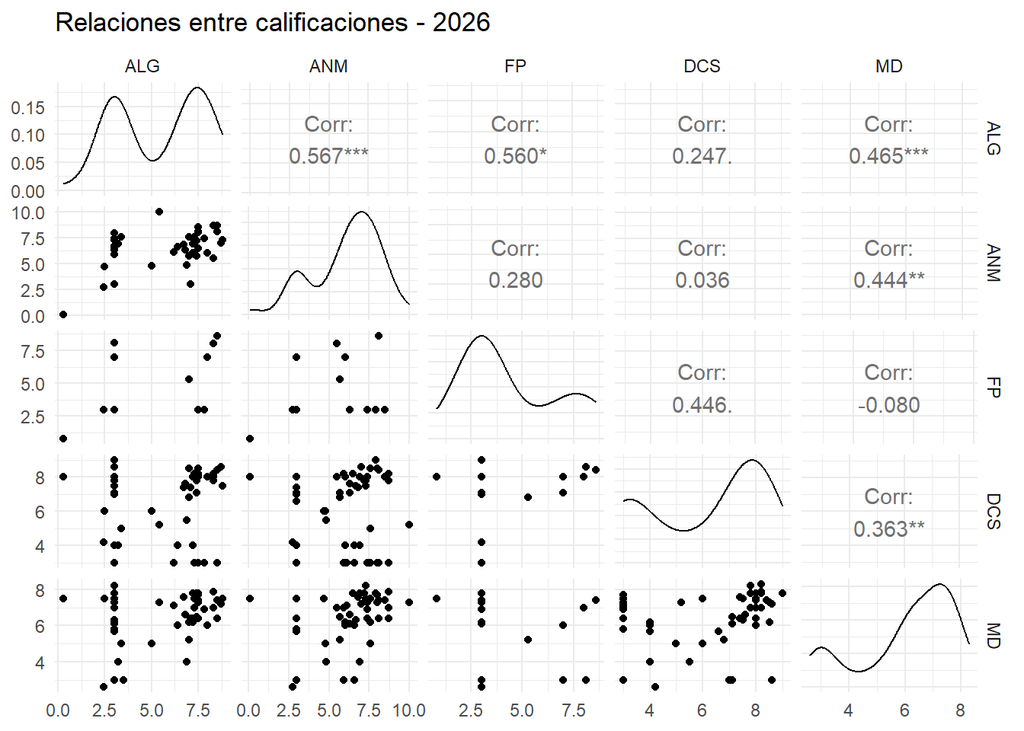

```r
notas2026 %>%
  select(all_of(asignaturas)) %>%
  ggpairs(title = "Relaciones entre calificaciones - 2026") +
  theme_minimal()
```

## Matrices de correlación y covarianza

```r
matrices_cor <- function(notas, anyo) {
  notas_num    <- notas %>% select(all_of(asignaturas)) %>% drop_na()
  cor_pearson  <- cor(notas_num, method = "pearson")
  cor_spearman <- cor(notas_num, method = "spearman")
  cov_mat      <- cov(notas_num)

  cat("===", anyo, "- Correlación Pearson ===\n");  print(round(cor_pearson,  2))
  cat("===", anyo, "- Correlación Spearman ===\n"); print(round(cor_spearman, 2))
  cat("===", anyo, "- Covarianza ===\n");            print(round(cov_mat,      2))

  # Par con mayor correlación (fuera de la diagonal)
  cor_aux <- cor_pearson
  diag(cor_aux) <- NA
  idx <- which(abs(cor_aux) == max(abs(cor_aux), na.rm = TRUE), arr.ind = TRUE)
  cat("Par con mayor correlación Pearson:", rownames(idx)[1], "y",
      colnames(cor_pearson)[idx[1, 2]], "=",
      round(cor_pearson[idx[1,1], idx[1,2]], 3), "\n\n")
}

matrices_cor(notas2022, "2022")
```

```
## === 2022 - Correlación Pearson ===
##      ALG  ANM   FP  DCS   MD
## ALG 1.00 0.71 0.55 0.33 0.80
## ANM 0.71 1.00 0.61 0.56 0.62
## FP  0.55 0.61 1.00 0.51 0.72
## DCS 0.33 0.56 0.51 1.00 0.50
## MD  0.80 0.62 0.72 0.50 1.00
## === 2022 - Correlación Spearman ===
##      ALG  ANM   FP  DCS   MD
## ALG 1.00 0.60 0.62 0.28 0.86
## ANM 0.60 1.00 0.70 0.53 0.58
## FP  0.62 0.70 1.00 0.46 0.73
## DCS 0.28 0.53 0.46 1.00 0.33
## MD  0.86 0.58 0.73 0.33 1.00
## === 2022 - Covarianza ===
##      ALG  ANM   FP  DCS   MD
## ALG 2.68 1.58 2.03 0.81 2.23
## ANM 1.58 1.86 1.89 1.13 1.45
## FP  2.03 1.89 5.08 1.70 2.77
## DCS 0.81 1.13 1.70 2.22 1.27
## MD  2.23 1.45 2.77 1.27 2.90
## Par con mayor correlación Pearson: MD y ALG = 0.801
```

```r
matrices_cor(notas2026, "2026")
```

```
## === 2026 - Correlación Pearson ===
##      ALG  ANM   FP  DCS   MD
## ALG 1.00 0.65 0.67 0.19 0.35
## ANM 0.65 1.00 0.28 0.10 0.60
## FP  0.67 0.28 1.00 0.36 0.01
## DCS 0.19 0.10 0.36 1.00 0.36
## MD  0.35 0.60 0.01 0.36 1.00
## === 2026 - Correlación Spearman ===
##      ALG  ANM    FP  DCS    MD
## ALG 1.00 0.60  0.75 0.29  0.21
## ANM 0.60 1.00  0.22 0.31  0.58
## FP  0.75 0.22  1.00 0.31 -0.13
## DCS 0.29 0.31  0.31 1.00  0.61
## MD  0.21 0.58 -0.13 0.61  1.00
## === 2026 - Covarianza ===
##      ALG  ANM   FP  DCS   MD
## ALG 7.90 4.68 4.46 1.15 1.94
## ANM 4.68 6.54 1.70 0.58 3.03
## FP  4.46 1.70 5.65 1.88 0.06
## DCS 1.15 0.58 1.88 4.77 1.54
## MD  1.94 3.03 0.06 1.54 3.93
## Par con mayor correlación Pearson: FP y ALG = 0.667
```

## Boxplots de todas las asignaturas

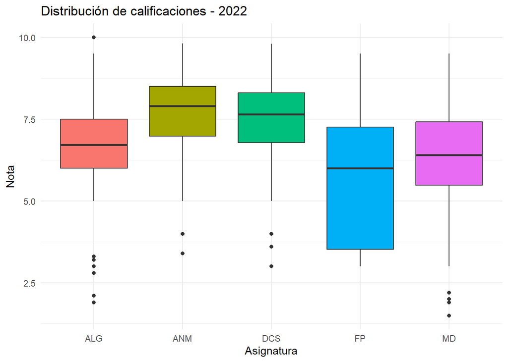

```r
boxplot_notas <- function(notas, anyo) {
  notas %>%
    pivot_longer(all_of(asignaturas), names_to = "Asignatura", values_to = "Nota") %>%
    ggplot(aes(x = Asignatura, y = Nota, fill = Asignatura)) +
    geom_boxplot() +
    labs(title = paste("Distribución de calificaciones -", anyo)) +
    theme_minimal() +
    theme(legend.position = "none")
}

boxplot_notas(notas2022, "2022")
```

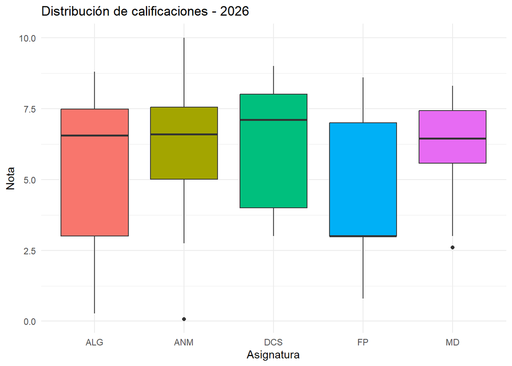

```r
boxplot_notas(notas2026, "2026")
```

## Boxplot coloreado por sexo

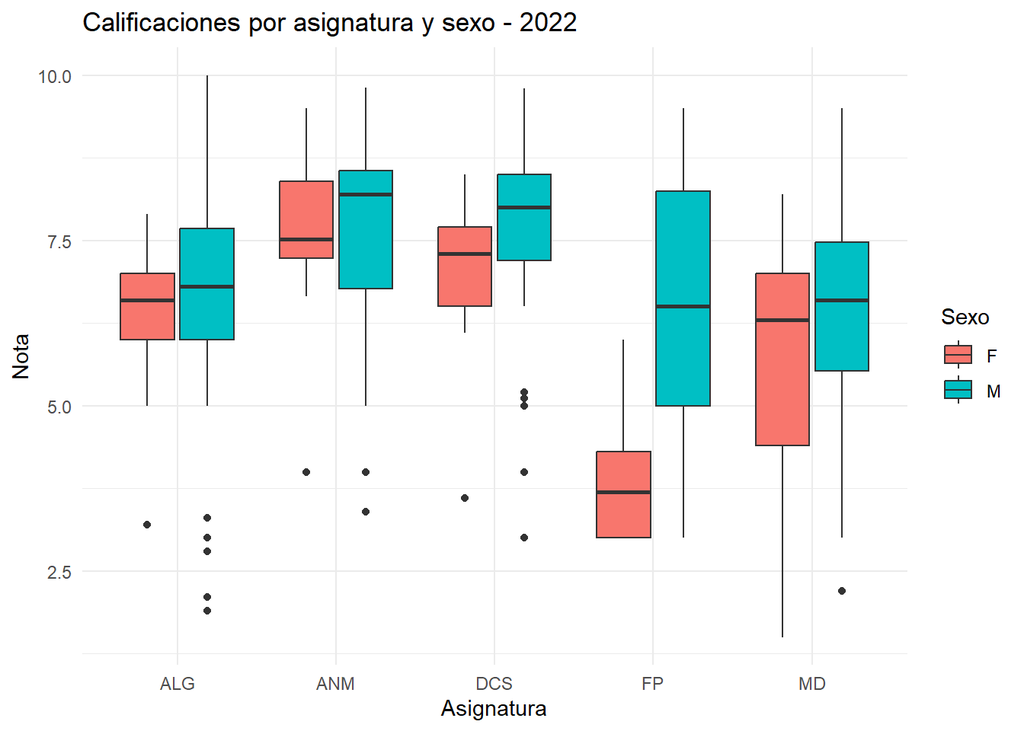

```r
# Limpieza de sexo (válida para ambos años)
limpiar_sexo <- function(datos) {
  datos %>%
    mutate(Sex_clean = case_when(
      str_to_upper(str_trim(Sex)) %in% c("M", "MASCULINO", "HOMBRE") ~ "M",
      str_to_upper(str_trim(Sex)) %in% c("F", "FEMENINO",  "MUJER")  ~ "F",
      TRUE ~ NA_character_
    ))
}

boxplot_sexo <- function(notas, datos, anyo) {
  datos_sexo <- limpiar_sexo(datos) %>% select(Id, Sex_clean)
  notas %>%
    left_join(datos_sexo, by = "Id") %>%
    filter(!is.na(Sex_clean)) %>%
    pivot_longer(all_of(asignaturas), names_to = "Asignatura", values_to = "Nota") %>%
    ggplot(aes(x = Asignatura, y = Nota, fill = Sex_clean)) +
    geom_boxplot() +
    labs(title = paste("Calificaciones por asignatura y sexo -", anyo), fill = "Sexo") +
    theme_minimal()
}

boxplot_sexo(notas2022, datos2022, "2022")
```

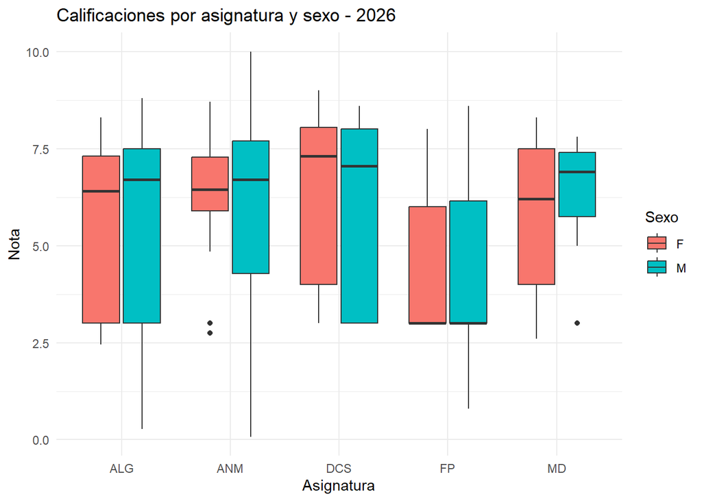

```r
boxplot_sexo(notas2026, datos2026, "2026")
```

## Gráfico de líneas: alumnos con todas las notas

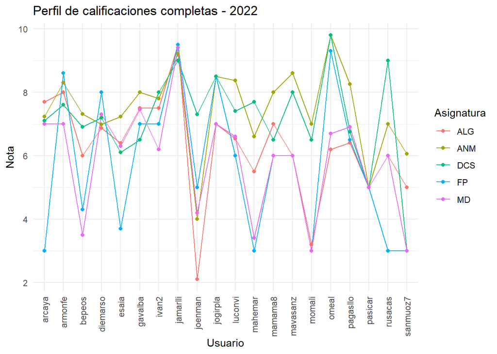

```r
grafico_lineas <- function(notas, anyo) {
  completos <- notas %>%
    filter(if_all(all_of(asignaturas), ~ !is.na(.)))

  if (nrow(completos) == 0) {
    cat("No hay alumnos con todas las notas en", anyo, "\n")
    return(invisible(NULL))
  }

  completos %>%
    pivot_longer(all_of(asignaturas), names_to = "Asignatura", values_to = "Nota") %>%
    ggplot(aes(x = Id, y = Nota, color = Asignatura, group = Asignatura)) +
    geom_line() +
    geom_point() +
    theme_minimal() +
    theme(axis.text.x = element_text(angle = 90, vjust = 0.5, hjust = 1)) +
    labs(title = paste("Perfil de calificaciones completas -", anyo),
         x = "Usuario", y = "Nota")
}

grafico_lineas(notas2022, "2022")
```

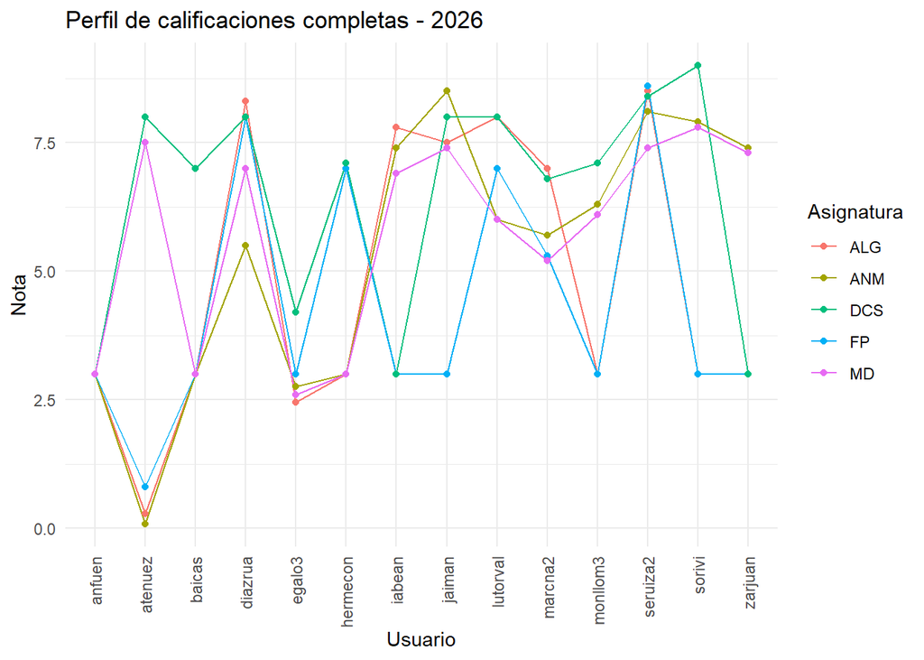

```r
grafico_lineas(notas2026, "2026")
```

```r
cat("Comparación 2022 vs 2026: la nota media global fue",
    round(mean(unlist(notas2022[,asignaturas]), na.rm=TRUE), 2),
    "en 2022 y",
    round(mean(unlist(notas2026[,asignaturas]), na.rm=TRUE), 2),
    "en 2026.\n")
```

```
## Comparación 2022 vs 2026: la nota media global fue 6.8 en 2022 y 5.84 en 2026.
```

## Preguntas específicas del curso 2026

```r
# Limpiamos todas las variables problemáticas detectadas en los datos reales:
datos26 <- datos2026 %>%
  mutate(
    FechaNac = dmy(`FechaNac(DD-MM-YYY)`),

    Smoke = case_when(
      str_to_upper(str_trim(Smoke)) %in% c("SI", "SÍ", "YES") ~ "Si",
      str_to_upper(str_trim(Smoke)) %in% c("NO")              ~ "No",
      TRUE ~ NA_character_
    ),

    NW.Hnd = case_when(
      str_to_title(str_trim(NW.Hnd)) == "Derecha"   ~ "Derecha",
      str_to_title(str_trim(NW.Hnd)) == "Izquierda" ~ "Izquierda",
      TRUE ~ NA_character_
    ),

    Sex = case_when(
      str_to_upper(str_trim(Sex)) %in% c("M", "MASCULINO") ~ "M",
      str_to_upper(str_trim(Sex)) %in% c("F", "FEMENINO")  ~ "F",
      TRUE ~ NA_character_
    ),

    # Numéricas con coma decimal
    Wr.Hnd = as.numeric(str_replace_all(as.character(Wr.Hnd), ",", ".")),
    Hwork  = as.numeric(str_replace_all(as.character(Hwork),  ",", ".")),
    Pulse  = as.numeric(Pulse),
    Height = as.numeric(Height)
  )
```

## Preguntas:

### 1. ¿Qué edad, expresada en años (con decimales) tiene el alumno más joven a fecha 01/02/2026.

```r
fecha_ref <- ymd("2026-02-01")

datos26 <- datos26 %>%
  mutate(Edad = as.numeric(difftime(fecha_ref, FechaNac, units = "days")) / 365.25)

joven <- datos26 %>% slice_min(Edad, n = 1)

cat("Alumno más joven:", joven$Id, "\n")
```

```
## Alumno más joven: gipicar
```

```r
cat("Edad a 01/02/2026:", round(joven$Edad, 4), "años\n")
```

```
## Edad a 01/02/2026: 18.1218 años
```

### 2. Cuántos alumnos simultanean trabajo y estudios.

```r
trabajadores <- datos26 %>% filter(!is.na(Hwork) & Hwork > 0)

cat("Alumnos que simultanean trabajo y estudios:", nrow(trabajadores), "\n")
```

```
## Alumnos que simultanean trabajo y estudios: 14
```

```r
print(trabajadores %>% select(Id, Hwork))
```

```
## # A tibble: 14 × 2
##    Id       Hwork
##    <chr>    <dbl>
##  1 sorivi      28
##  2 Jorica3     30
##  3 andanomi    25
##  4 sasot       20
##  5 antanuez     9
##  6 anvanro     20
##  7 topapas2     8
##  8 egalo3       3
##  9 aceva        8
## 10 juales2      2
## 11 a29          3
## 12 monllom3     8
## 13 majuanm4    15
## 14 lulogar2     3
```

### 3. Hay más hombres o más mujeres fumadoras.

```r
tabla_fum <- table(datos26$Sex, datos26$Smoke, useNA = "ifany")
print(tabla_fum)
```

```
##
##     No Si
##   F 24  0
##   M 29  7
```

```r
hom_fum <- tabla_fum["M", "Si"]
muj_fum <- tabla_fum["F", "Si"]

if (hom_fum > muj_fum) {
  cat("Hay más hombres fumadores (", hom_fum, "H vs", muj_fum, "M)\n")
} else if (muj_fum > hom_fum) {
  cat("Hay más mujeres fumadoras (", muj_fum, "M vs", hom_fum, "H)\n")
} else {
  cat("Mismo número de hombres y mujeres fumadores (", hom_fum, "cada uno)\n")
}
```

```
## Hay más hombres fumadores ( 7 H vs 0 M)
```

### 4. Cuál es el valor medio y la varianza de la variable Wr.Hnd según el sexo.

```r
datos26 %>%
  group_by(Sex) %>%
  summarise(
    Media    = round(mean(Wr.Hnd, na.rm = TRUE), 2),
    Varianza = round(var(Wr.Hnd,  na.rm = TRUE), 2),
    .groups  = "drop"
  ) %>%
  kable(caption = "Media y varianza de Wr.Hnd según sexo")
```

Media y varianza de Wr.Hnd según sexo

| Sex | Media | Varianza |
| --- | --- | --- |
| F | 18.04 | 3.72 |
| M | 19.99 | 1.73 |

### 5. Determina si existe relación entre el sexo y la mano con la que se escribe (NW.Hnd)

```r
tabla_mano <- table(datos26$Sex, datos26$NW.Hnd)
print(tabla_mano)
```

```
##
##     Derecha Izquierda
##   F      22         2
##   M      29         7
```

```r
chi2 <- chisq.test(tabla_mano, correct = FALSE)
print(chi2)
```

```
##
##  Pearson's Chi-squared test
##
## data:  tabla_mano
## X-squared = 1.3943, df = 1, p-value = 0.2377
```

```r
if (chi2$p.value < 0.05) {
  cat("Existe relación significativa entre sexo y mano de escritura.\n")
} else {
  cat("No hay evidencia de relación entre sexo y mano de escritura\n")
}
```

```
## No hay evidencia de relación entre sexo y mano de escritura
```

### 6. Existe una relación lineal entre la altura (Height) y la distancia del extremo del meñique al extremo del pulgar de la mano con la que escribimos (Wr.Hnd)

```r
cor(datos26$Height, datos26$Wr.Hnd, method = "pearson", use = "complete.obs")
```

```
## [1] 0.4310869
```

### 7. El identificador de Hampel detecta algún outlier en la variable altura.

```r
x      <- datos26$Height
med_h  <- median(x, na.rm = TRUE)
mad_h  <- mad(x,    na.rm = TRUE)   # incluye factor 1.4826
upLim  <- med_h + 3 * mad_h
lowLim <- med_h - 3 * mad_h

cat("Mediana:", med_h, "| MAD:", round(mad_h, 3), "\n")
```

```
## Mediana: 173.5 | MAD: 10.378
```

```r
cat("Intervalo valores normales: [", round(lowLim, 3), ",", round(upLim, 3), "]\n\n")
```

```
## Intervalo valores normales: [ 142.365 , 204.635 ]
```

```r
outliers_h <- datos26 %>%
  filter(!is.na(Height) & (Height < lowLim | Height > upLim))

cat("Número de outliers detectados:", nrow(outliers_h), "\n")
```

```
## Número de outliers detectados: 0
```

```r
if (nrow(outliers_h) > 0) {
  print(outliers_h %>% select(Id, Height))
} else {
  cat("El identificador de Hampel no detecta ningún outlier en Height.\n")
}
```

```
## El identificador de Hampel no detecta ningún outlier en Height.
```

### 8. Considera la asignatura FP. Si queremos realizar una imputación generalizada usando la media, ¿qué valor deberíamos utilizar ?

```r
media_FP <- mean(notas2026$FP, na.rm = TRUE)

cat("Valor para imputación generalizada de FP (media):", round(media_FP, 2), "\n")
```

```
## Valor para imputación generalizada de FP (media): 4.4
```

```r
cat("Número de valores NA en FP:", sum(is.na(notas2026$FP)), "\n")
```

```
## Número de valores NA en FP: 43
```

### 9. Define una nueva variable (PulseCat) a partir del ritmo cardíaco (Pulse), con dos valores PulseH, si Pulse>=65 y PulseL si Pulse<65. ¿Qué valores utilizarías para imputar los valores faltantes de las notas de FP, dependiendo del valor de PulseCat (imputación por casos similares)

```r
datos26 <- datos26 %>%
  mutate(PulseCat = if_else(Pulse >= 65, "PulseH", "PulseL", missing = NA_character_))

# Calculamos medias de FP por categoría (solo las que tienen datos)
medias_FP_cat <- notas2026 %>%
  inner_join(datos26 %>% select(Id, PulseCat), by = "Id") %>%
  group_by(PulseCat) %>%
  summarise(Media_FP = mean(FP, na.rm = TRUE), .groups = "drop")

print(medias_FP_cat)
```

```
## # A tibble: 3 × 2
##   PulseCat Media_FP
##   <chr>       <dbl>
## 1 PulseH       5.1
## 2 PulseL       4.14
## 3 <NA>         3
```

```r
# Extraemos valores para imputación (sin NA)
media_H <- medias_FP_cat %>% filter(PulseCat == "PulseH") %>% pull(Media_FP)
media_L <- medias_FP_cat %>% filter(PulseCat == "PulseL") %>% pull(Media_FP)

cat("Para imputar FP por casos similares:\n")
```

```
## Para imputar FP por casos similares:
```

```r
cat("  Alumnos con PulseH: usar", round(media_H, 2), "\n")
```

```
##   Alumnos con PulseH: usar 5.1
```

```r
cat("  Alumnos con PulseL: usar", round(media_L, 2), "\n")
```

```
##   Alumnos con PulseL: usar 4.14
```